# Reproducibility R news

Mikołaj Malec

3/30/2020

# Reproducibility of R news (7/3 2007) articles:

sorce: https://www.r-project.org/doc/Rnews/Rnews_2007-3.pdf

## SpherWave: An R Package for Analyzing Scattered Spherical Data by Spherical Wavelets

```r
try( library("SpherWave"))
```

```
## Error in library("SpherWave") : there is no package called 'SpherWave'
```

There is no posibility to download SherWave. It’s not updated since 2017, so it’s not working on R version 3.6.1. In the end this article is unreproducible.

Sorce of SherWave: https://rdrr.io/cran/SpherWave/man/

## Diving Behaviour Analysis in R

The diveMove package provides tools for analyzing diving behaviour, including convenient methods for the visualization of the typically large amounts of data collected by TDRs.

```r
library("diveMove")
```

It’s possible that there was a small change in .scv file. Now it’s seperated by “;”.

```r
ff <- system.file(file.path("data",
                            "dives.csv"), package = "diveMove")
tdrXcsv <- read.csv(ff,sep = ";") #change from (sep = ";")
```

No problems with code below.

```r
ddtt.str <- paste(tdrXcsv$date,
                  tdrXcsv$time)
ddtt <- strptime(ddtt.str,
                 format = "%d/%m/%Y %H:%M:%S")
time.posixct <- as.POSIXct(ddtt,
                           tz = "GMT")

tdrX <- createTDR(time = time.posixct,
                  depth = tdrXcsv$depth,
                  concurrentData = tdrXcsv[,-c(1:3)],
                  dtime = 5,
                  file = ff)

tdrX <- createTDR(time = time.posixct,
                     depth = tdrXcsv$depth,
                     concurrentData = tdrXcsv[,-c(1:3)],
                     dtime = 5,
                     file = ff,
                  speed = TRUE)
```

*readTDR* has the same problem as above chank. Function *plotTDR* has drasticli changed. It doesn’t show speed and it plots data in diffrent way (not by giving TDR object, but by giving time and depth vector). I couldn’t make this plot interactiv.

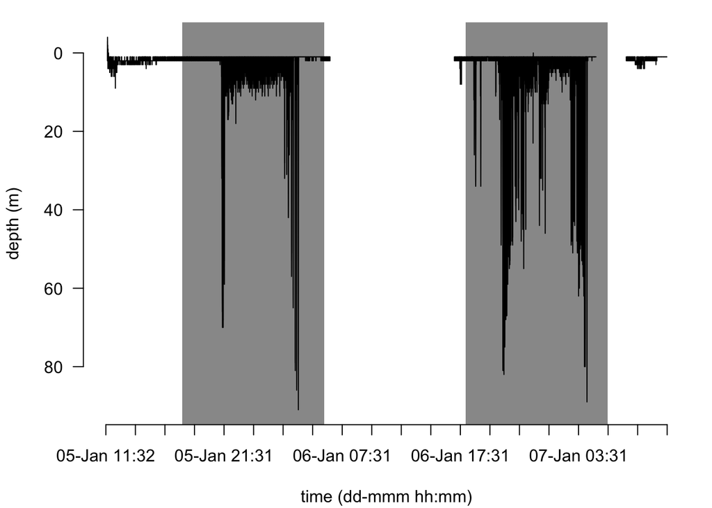

```r
#orginal code (not working)
#tdrX <- readTDR(ff, speed = TRUE)
#plotTDR(tdrX)
#fixed code
tdrX <- readTDR(ff, sep = ";", speed = TRUE)
plotTDR( getTime( tdrX), getDepth( tdrX), interact=FALSE)
```

*calibrateDepth* in example is not working becouse of some iner-funcion computacion. Example shown in the R Documentation is working.

```r
#orginal code (not working)
#calib <- calibrateDepth(tdrX)
#dcalib <- calibrateDepth(tdrX, offset = 3)
#dcalib <- calibrateDepth(tdrX, offset = 3, wet.thr = 70, dry.thr = 3610, dive.thr = 4, descent.crit.q = 0.1, ascent.crit.q = 0.1, wiggle.tol = 0.8)

#fixed code
dcalib <- calibrateDepth(tdrX, dive.thr=3, zoc.method="offset",
                          offset=3, descent.crit.q=0.01, ascent.crit.q=0,
                          knot.factor=20)
```

```
## Record is complete
## 7 phases detected
```

```
## 426 dives detected
```

Unkown error, it’s posible that it is not reproducibile.

```r
try({
#orginal (not working)
plotTDR(dcalib, concurVars = "light",
        concurVarTitles = c("speed (m/s)","light"),
        surface = TRUE)
})
```

```
## Error in .local(x, y, ...) : identical(lcvt, lcv) is not TRUE
```

Differnt color but mosly the same plot as orginal. Also small change in semantics and no speed plot.

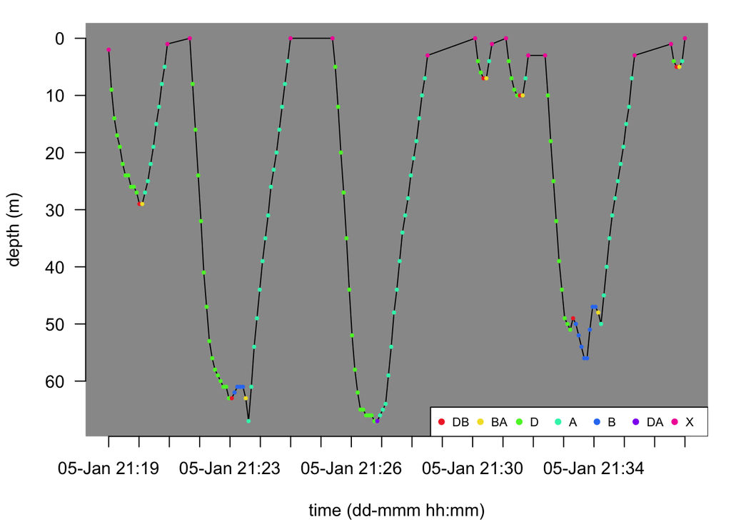

```r
#plotTDR(dcalib, diveNo = 2:8, labels = "dive.phase")
plotTDR(dcalib, diveNo=2:8, what="phases", interact=FALSE)
```

*calibrateSpeed* is working.

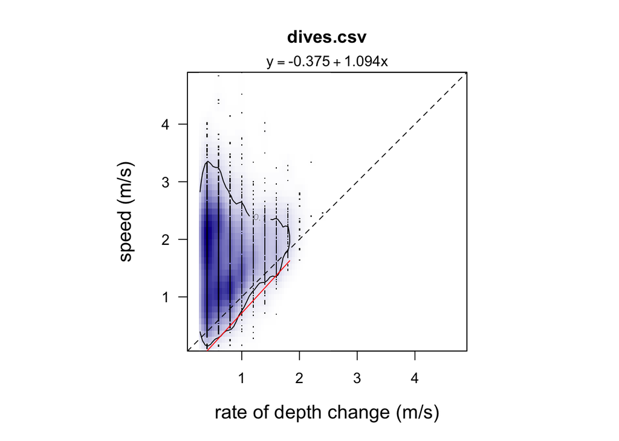

```r
vcalib <- calibrateSpeed(dcalib,
                         tau = 0.1, contour.level = 0.1,
                         z = 1, bad = c(0, 0),
                         cex.pts = 0.2)
```

Sumary: Alticle was made in December of 2007. Since then there were possible many changes to *diveMove* packkage and in one point lost beeing backward compatible. Maby code used in this aricle is out-off date (so unreproducible today), but it’s still usefull sorce of information about *diveMove* packkage.

## Very Large Numbers in R: Introducing Package Brobdingnag

The Brobdingnag package allows representation and manipulation of numbers larger than those covered by standard double precision arithmetic, al- though accuracy is eroded for very large numbers. This facility is useful in several contexts, including combinatorial computations such as encountered in theoretical modelling of biodiversity.

```r
library( Brobdingnag)
googol <- as.brob(10)^100
googol
```

```
## [1] +exp(230.26)
```

```r
stirling <- function(n) { n^n * exp(-n) * sqrt(2 * pi * n) }
stirling(googol)
```

```
## [1] +exp(2.2926e+102)
```

```r
2^(1/googol)
```

```
## [1] +exp(6.9315e-101)
```

```r
#should be zero
f <- function(x){
  as.numeric( (pi*x -3*x -(pi-3)*x)/x)
}

print( c(f(1/7), f(as.brob(1/7)), f(1e+100), f(as.brob(1e+100)), f(as.brob(10)^1000)))
```

```
## [1]  1.700029e-16 -1.886393e-16 -2.185503e-16 -3.219444e-14  1.931667e-13
```

All computations are equal to those in article. Or base code wasn’t cahnged since 2007 or its authors of this package are very good in backward compatiblity